# Risk Factor Analysis

## Outcome Variable

**Outcome Variable:** stunted

## Predictor Variables

**Intervention Variable:** nhh

**Adjustment Set:**

unadjusted

## Stratifying Variables

The analysis was stratified on these variable(s):

- agecat
- studyid
- country

## Data Summary

| agecat | studyid | country | nhh | stunted | n_cell | n |
| --- | --- | --- | --- | --- | --- | --- |
| Birth | ki1000108-IRC | INDIA | 3 or less | 0 | 51 | 388 |
| Birth | ki1000108-IRC | INDIA | 3 or less | 1 | 3 | 388 |
| Birth | ki1000108-IRC | INDIA | 4-5 | 0 | 128 | 388 |
| Birth | ki1000108-IRC | INDIA | 4-5 | 1 | 22 | 388 |
| Birth | ki1000108-IRC | INDIA | 6-7 | 0 | 89 | 388 |
| Birth | ki1000108-IRC | INDIA | 6-7 | 1 | 14 | 388 |
| Birth | ki1000108-IRC | INDIA | 8+ | 0 | 75 | 388 |
| Birth | ki1000108-IRC | INDIA | 8+ | 1 | 6 | 388 |
| Birth | ki1017093-NIH-Birth | BANGLADESH | 3 or less | 0 | 93 | 608 |
| Birth | ki1017093-NIH-Birth | BANGLADESH | 3 or less | 1 | 19 | 608 |
| Birth | ki1017093-NIH-Birth | BANGLADESH | 4-5 | 0 | 214 | 608 |
| Birth | ki1017093-NIH-Birth | BANGLADESH | 4-5 | 1 | 41 | 608 |
| Birth | ki1017093-NIH-Birth | BANGLADESH | 6-7 | 0 | 118 | 608 |
| Birth | ki1017093-NIH-Birth | BANGLADESH | 6-7 | 1 | 20 | 608 |
| Birth | ki1017093-NIH-Birth | BANGLADESH | 8+ | 0 | 86 | 608 |
| Birth | ki1017093-NIH-Birth | BANGLADESH | 8+ | 1 | 17 | 608 |
| Birth | ki1017093b-PROVIDE | BANGLADESH | 3 or less | 0 | 96 | 539 |
| Birth | ki1017093b-PROVIDE | BANGLADESH | 3 or less | 1 | 8 | 539 |
| Birth | ki1017093b-PROVIDE | BANGLADESH | 4-5 | 0 | 227 | 539 |
| Birth | ki1017093b-PROVIDE | BANGLADESH | 4-5 | 1 | 24 | 539 |
| Birth | ki1017093b-PROVIDE | BANGLADESH | 6-7 | 0 | 107 | 539 |
| Birth | ki1017093b-PROVIDE | BANGLADESH | 6-7 | 1 | 9 | 539 |
| Birth | ki1017093b-PROVIDE | BANGLADESH | 8+ | 0 | 61 | 539 |
| Birth | ki1017093b-PROVIDE | BANGLADESH | 8+ | 1 | 7 | 539 |
| Birth | ki1017093c-NIH-Crypto | BANGLADESH | 3 or less | 0 | 89 | 732 |
| Birth | ki1017093c-NIH-Crypto | BANGLADESH | 3 or less | 1 | 19 | 732 |
| Birth | ki1017093c-NIH-Crypto | BANGLADESH | 4-5 | 0 | 285 | 732 |
| Birth | ki1017093c-NIH-Crypto | BANGLADESH | 4-5 | 1 | 43 | 732 |
| Birth | ki1017093c-NIH-Crypto | BANGLADESH | 6-7 | 0 | 151 | 732 |
| Birth | ki1017093c-NIH-Crypto | BANGLADESH | 6-7 | 1 | 25 | 732 |

[output cut: 90 more lines]

The following strata were considered:

- agecat: 24 months, studyid: ki1000108-IRC, country: INDIA
- agecat: 24 months, studyid: ki1017093-NIH-Birth, country: BANGLADESH
- agecat: 24 months, studyid: ki1017093b-PROVIDE, country: BANGLADESH
- agecat: 24 months, studyid: ki1017093c-NIH-Crypto, country: BANGLADESH
- agecat: 24 months, studyid: ki1148112-LCNI-5, country: MALAWI
- agecat: 6 months, studyid: ki1000108-IRC, country: INDIA
- agecat: 6 months, studyid: ki1000304b-SAS-FoodSuppl, country: INDIA
- agecat: 6 months, studyid: ki1017093-NIH-Birth, country: BANGLADESH
- agecat: 6 months, studyid: ki1017093b-PROVIDE, country: BANGLADESH
- agecat: 6 months, studyid: ki1017093c-NIH-Crypto, country: BANGLADESH
- agecat: 6 months, studyid: ki1148112-LCNI-5, country: MALAWI
- agecat: Birth, studyid: ki1000108-IRC, country: INDIA
- agecat: Birth, studyid: ki1017093-NIH-Birth, country: BANGLADESH
- agecat: Birth, studyid: ki1017093b-PROVIDE, country: BANGLADESH
- agecat: Birth, studyid: ki1017093c-NIH-Crypto, country: BANGLADESH

### Dropped Strata

Some strata were dropped due to rare outcomes:

- agecat: Birth, studyid: ki1000108-IRC, country: INDIA

## Methods Detail

We’re interested in the causal parameters $E[Y_a]$ for all values of $a \in \mathcal{A}$. These parameters represent the mean outcome if, possibly contrary to fact, we intervened to set all units to have $A=a$. Under the randomization and positivity assumptions, these are identified by the statistical parameters $\psi_a=E_W[E_{Y|A,W}(Y|A=a,W)]$. In addition, we’re interested in the mean of $Y$, $E[Y]$ under no intervention (the observed mean). We will estimate these parameters by using SuperLearner to fit the relevant likelihood factors – $E_{Y|A,W}(Y|A=a,W)$ and $p(A=a|W)$, and then updating our likelihood fit using a joint TMLE.

For unadjusted analyses ($W=\{\}$), initial likelihoods were estimated using Lrnr_glm to estimate the simple $E(Y|A)$ and Lrnr_mean to estimate $p(A)$. For adjusted analyses, a small library containing Lrnr_glmnet, Lrnr_xgboost, and Lrnr_mean was used.

Having estimated these parameters, we will then use the delta method to estimate relative risks and attributable risks relative to a prespecified baseline level of $A$.

# Results Detail

## Results Plots

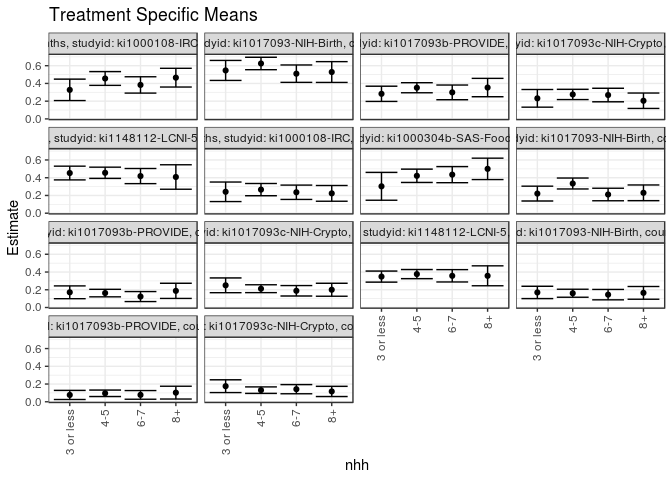

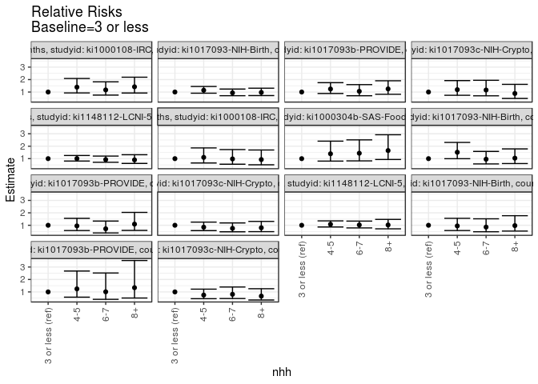

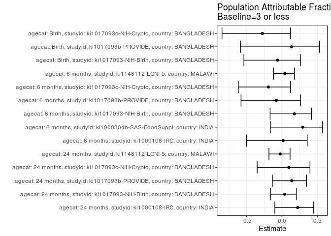

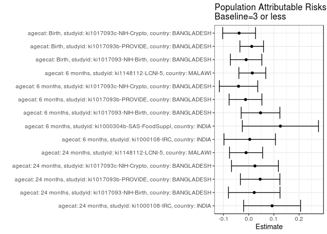

## Results Table

### Parameter: TSM

| agecat | studyid | country | intervention_level | baseline_level | estimate | ci_lower | ci_upper |
| --- | --- | --- | --- | --- | --- | --- | --- |
| Birth | ki1017093-NIH-Birth | BANGLADESH | 3 or less | NA | 0.1696429 | 0.1000769 | 0.2392088 |
| Birth | ki1017093-NIH-Birth | BANGLADESH | 4-5 | NA | 0.1607843 | 0.1156617 | 0.2059069 |
| Birth | ki1017093-NIH-Birth | BANGLADESH | 6-7 | NA | 0.1449275 | 0.0861457 | 0.2037093 |
| Birth | ki1017093-NIH-Birth | BANGLADESH | 8+ | NA | 0.1650485 | 0.0932983 | 0.2367988 |
| Birth | ki1017093b-PROVIDE | BANGLADESH | 3 or less | NA | 0.0769231 | 0.0256627 | 0.1281835 |
| Birth | ki1017093b-PROVIDE | BANGLADESH | 4-5 | NA | 0.0956175 | 0.0592043 | 0.1320308 |
| Birth | ki1017093b-PROVIDE | BANGLADESH | 6-7 | NA | 0.0775862 | 0.0288583 | 0.1263141 |
| Birth | ki1017093b-PROVIDE | BANGLADESH | 8+ | NA | 0.1029412 | 0.0306472 | 0.1752351 |
| Birth | ki1017093c-NIH-Crypto | BANGLADESH | 3 or less | NA | 0.1759259 | 0.1040669 | 0.2477849 |
| Birth | ki1017093c-NIH-Crypto | BANGLADESH | 4-5 | NA | 0.1310976 | 0.0945473 | 0.1676479 |
| Birth | ki1017093c-NIH-Crypto | BANGLADESH | 6-7 | NA | 0.1420455 | 0.0904354 | 0.1936555 |
| Birth | ki1017093c-NIH-Crypto | BANGLADESH | 8+ | NA | 0.1166667 | 0.0591902 | 0.1741431 |
| 6 months | ki1000108-IRC | INDIA | 3 or less | NA | 0.2413793 | 0.1311161 | 0.3516425 |
| 6 months | ki1000108-IRC | INDIA | 4-5 | NA | 0.2658228 | 0.1968544 | 0.3347912 |
| 6 months | ki1000108-IRC | INDIA | 6-7 | NA | 0.2358491 | 0.1549328 | 0.3167654 |
| 6 months | ki1000108-IRC | INDIA | 8+ | NA | 0.2235294 | 0.1348541 | 0.3122047 |
| 6 months | ki1000304b-SAS-FoodSuppl | INDIA | 3 or less | NA | 0.3030303 | 0.1460254 | 0.4600352 |
| 6 months | ki1000304b-SAS-FoodSuppl | INDIA | 4-5 | NA | 0.4216867 | 0.3464651 | 0.4969084 |
| 6 months | ki1000304b-SAS-FoodSuppl | INDIA | 6-7 | NA | 0.4347826 | 0.3440601 | 0.5255051 |
| 6 months | ki1000304b-SAS-FoodSuppl | INDIA | 8+ | NA | 0.5000000 | 0.3792135 | 0.6207865 |
| 6 months | ki1017093-NIH-Birth | BANGLADESH | 3 or less | NA | 0.2210526 | 0.1375322 | 0.3045731 |
| 6 months | ki1017093-NIH-Birth | BANGLADESH | 4-5 | NA | 0.3348018 | 0.2733535 | 0.3962500 |
| 6 months | ki1017093-NIH-Birth | BANGLADESH | 6-7 | NA | 0.2109375 | 0.1401950 | 0.2816800 |
| 6 months | ki1017093-NIH-Birth | BANGLADESH | 8+ | NA | 0.2298851 | 0.1413885 | 0.3183816 |
| 6 months | ki1017093b-PROVIDE | BANGLADESH | 3 or less | NA | 0.1714286 | 0.0992813 | 0.2435758 |
| 6 months | ki1017093b-PROVIDE | BANGLADESH | 4-5 | NA | 0.1626298 | 0.1200486 | 0.2052109 |
| 6 months | ki1017093b-PROVIDE | BANGLADESH | 6-7 | NA | 0.1230769 | 0.0665565 | 0.1795973 |
| 6 months | ki1017093b-PROVIDE | BANGLADESH | 8+ | NA | 0.1875000 | 0.1018997 | 0.2731003 |
| 6 months | ki1017093c-NIH-Crypto | BANGLADESH | 3 or less | NA | 0.2500000 | 0.1667209 | 0.3332791 |
| 6 months | ki1017093c-NIH-Crypto | BANGLADESH | 4-5 | NA | 0.2116564 | 0.1672837 | 0.2560292 |
| 6 months | ki1017093c-NIH-Crypto | BANGLADESH | 6-7 | NA | 0.1882353 | 0.1294332 | 0.2470374 |
| 6 months | ki1017093c-NIH-Crypto | BANGLADESH | 8+ | NA | 0.2000000 | 0.1268418 | 0.2731582 |
| 6 months | ki1148112-LCNI-5 | MALAWI | 3 or less | NA | 0.3482143 | 0.2857882 | 0.4106404 |
| 6 months | ki1148112-LCNI-5 | MALAWI | 4-5 | NA | 0.3764706 | 0.3249395 | 0.4280016 |
| 6 months | ki1148112-LCNI-5 | MALAWI | 6-7 | NA | 0.3571429 | 0.2874871 | 0.4267986 |
| 6 months | ki1148112-LCNI-5 | MALAWI | 8+ | NA | 0.3571429 | 0.2448264 | 0.4694594 |
| 24 months | ki1000108-IRC | INDIA | 3 or less | NA | 0.3275862 | 0.2066527 | 0.4485198 |
| 24 months | ki1000108-IRC | INDIA | 4-5 | NA | 0.4556962 | 0.3779446 | 0.5334478 |
| 24 months | ki1000108-IRC | INDIA | 6-7 | NA | 0.3831776 | 0.2909485 | 0.4754067 |
| 24 months | ki1000108-IRC | INDIA | 8+ | NA | 0.4651163 | 0.3595705 | 0.5706621 |
| 24 months | ki1017093-NIH-Birth | BANGLADESH | 3 or less | NA | 0.5466667 | 0.4338705 | 0.6594628 |
| 24 months | ki1017093-NIH-Birth | BANGLADESH | 4-5 | NA | 0.6250000 | 0.5549672 | 0.6950328 |
| 24 months | ki1017093-NIH-Birth | BANGLADESH | 6-7 | NA | 0.5100000 | 0.4119070 | 0.6080930 |
| 24 months | ki1017093-NIH-Birth | BANGLADESH | 8+ | NA | 0.5285714 | 0.4114960 | 0.6456468 |
| 24 months | ki1017093b-PROVIDE | BANGLADESH | 3 or less | NA | 0.2830189 | 0.1971901 | 0.3688476 |
| 24 months | ki1017093b-PROVIDE | BANGLADESH | 4-5 | NA | 0.3516484 | 0.2949589 | 0.4083378 |
| 24 months | ki1017093b-PROVIDE | BANGLADESH | 6-7 | NA | 0.2991453 | 0.2161055 | 0.3821851 |
| 24 months | ki1017093b-PROVIDE | BANGLADESH | 8+ | NA | 0.3536585 | 0.2500870 | 0.4572300 |
| 24 months | ki1017093c-NIH-Crypto | BANGLADESH | 3 or less | NA | 0.2318841 | 0.1322070 | 0.3315611 |
| 24 months | ki1017093c-NIH-Crypto | BANGLADESH | 4-5 | NA | 0.2758621 | 0.2182937 | 0.3334304 |
| 24 months | ki1017093c-NIH-Crypto | BANGLADESH | 6-7 | NA | 0.2692308 | 0.1929084 | 0.3455531 |
| 24 months | ki1017093c-NIH-Crypto | BANGLADESH | 8+ | NA | 0.2048193 | 0.1179132 | 0.2917254 |
| 24 months | ki1148112-LCNI-5 | MALAWI | 3 or less | NA | 0.4528302 | 0.3753917 | 0.5302687 |
| 24 months | ki1148112-LCNI-5 | MALAWI | 4-5 | NA | 0.4556962 | 0.3922346 | 0.5191578 |
| 24 months | ki1148112-LCNI-5 | MALAWI | 6-7 | NA | 0.4186047 | 0.3333988 | 0.5038106 |
| 24 months | ki1148112-LCNI-5 | MALAWI | 8+ | NA | 0.4081633 | 0.2704275 | 0.5458990 |

### Parameter: E(Y)

| agecat | studyid | country | intervention_level | baseline_level | estimate | ci_lower | ci_upper |
| --- | --- | --- | --- | --- | --- | --- | --- |
| Birth | ki1017093-NIH-Birth | BANGLADESH | NA | NA | 0.1595395 | 0.1304091 | 0.1886699 |
| Birth | ki1017093b-PROVIDE | BANGLADESH | NA | NA | 0.0890538 | 0.0649864 | 0.1131212 |
| Birth | ki1017093c-NIH-Crypto | BANGLADESH | NA | NA | 0.1379781 | 0.1129774 | 0.1629789 |
| 6 months | ki1000108-IRC | INDIA | NA | NA | 0.2457002 | 0.2038248 | 0.2875757 |
| 6 months | ki1000304b-SAS-FoodSuppl | INDIA | NA | NA | 0.4289474 | 0.3791199 | 0.4787748 |
| 6 months | ki1017093-NIH-Birth | BANGLADESH | NA | NA | 0.2681564 | 0.2306532 | 0.3056597 |
| 6 months | ki1017093b-PROVIDE | BANGLADESH | NA | NA | 0.1589404 | 0.1297581 | 0.1881227 |
| 6 months | ki1017093c-NIH-Crypto | BANGLADESH | NA | NA | 0.2097902 | 0.1799252 | 0.2396552 |
| 6 months | ki1148112-LCNI-5 | MALAWI | NA | NA | 0.3627451 | 0.3297365 | 0.3957537 |
| 24 months | ki1000108-IRC | INDIA | NA | NA | 0.4205379 | 0.3726382 | 0.4684376 |
| 24 months | ki1017093-NIH-Birth | BANGLADESH | NA | NA | 0.5687646 | 0.5218455 | 0.6156837 |
| 24 months | ki1017093b-PROVIDE | BANGLADESH | NA | NA | 0.3287197 | 0.2903909 | 0.3670485 |
| 24 months | ki1017093c-NIH-Crypto | BANGLADESH | NA | NA | 0.2568093 | 0.2190047 | 0.2946140 |
| 24 months | ki1148112-LCNI-5 | MALAWI | NA | NA | 0.4425087 | 0.4018409 | 0.4831765 |

### Parameter: RR

| agecat | studyid | country | intervention_level | baseline_level | estimate | ci_lower | ci_upper |
| --- | --- | --- | --- | --- | --- | --- | --- |
| Birth | ki1017093-NIH-Birth | BANGLADESH | 3 or less | 3 or less | 1.0000000 | 1.0000000 | 1.000000 |
| Birth | ki1017093-NIH-Birth | BANGLADESH | 4-5 | 3 or less | 0.9477812 | 0.5766377 | 1.557805 |
| Birth | ki1017093-NIH-Birth | BANGLADESH | 6-7 | 3 or less | 0.8543097 | 0.4798728 | 1.520914 |
| Birth | ki1017093-NIH-Birth | BANGLADESH | 8+ | 3 or less | 0.9729177 | 0.5352238 | 1.768548 |
| Birth | ki1017093b-PROVIDE | BANGLADESH | 3 or less | 3 or less | 1.0000000 | 1.0000000 | 1.000000 |
| Birth | ki1017093b-PROVIDE | BANGLADESH | 4-5 | 3 or less | 1.2430279 | 0.5769645 | 2.678013 |
| Birth | ki1017093b-PROVIDE | BANGLADESH | 6-7 | 3 or less | 1.0086207 | 0.4036851 | 2.520072 |
| Birth | ki1017093b-PROVIDE | BANGLADESH | 8+ | 3 or less | 1.3382353 | 0.5082528 | 3.523588 |
| Birth | ki1017093c-NIH-Crypto | BANGLADESH | 3 or less | 3 or less | 1.0000000 | 1.0000000 | 1.000000 |
| Birth | ki1017093c-NIH-Crypto | BANGLADESH | 4-5 | 3 or less | 0.7451861 | 0.4544520 | 1.221917 |
| Birth | ki1017093c-NIH-Crypto | BANGLADESH | 6-7 | 3 or less | 0.8074163 | 0.4673903 | 1.394811 |
| Birth | ki1017093c-NIH-Crypto | BANGLADESH | 8+ | 3 or less | 0.6631579 | 0.3496917 | 1.257617 |
| 6 months | ki1000108-IRC | INDIA | 3 or less | 3 or less | 1.0000000 | 1.0000000 | 1.000000 |
| 6 months | ki1000108-IRC | INDIA | 4-5 | 3 or less | 1.1012658 | 0.6512357 | 1.862285 |
| 6 months | ki1000108-IRC | INDIA | 6-7 | 3 or less | 0.9770889 | 0.5518536 | 1.729993 |
| 6 months | ki1000108-IRC | INDIA | 8+ | 3 or less | 0.9260504 | 0.5056838 | 1.695861 |
| 6 months | ki1000304b-SAS-FoodSuppl | INDIA | 3 or less | 3 or less | 1.0000000 | 1.0000000 | 1.000000 |
| 6 months | ki1000304b-SAS-FoodSuppl | INDIA | 4-5 | 3 or less | 1.3915663 | 0.8044999 | 2.407031 |
| 6 months | ki1000304b-SAS-FoodSuppl | INDIA | 6-7 | 3 or less | 1.4347826 | 0.8207455 | 2.508209 |
| 6 months | ki1000304b-SAS-FoodSuppl | INDIA | 8+ | 3 or less | 1.6500000 | 0.9315637 | 2.922505 |
| 6 months | ki1017093-NIH-Birth | BANGLADESH | 3 or less | 3 or less | 1.0000000 | 1.0000000 | 1.000000 |
| 6 months | ki1017093-NIH-Birth | BANGLADESH | 4-5 | 3 or less | 1.5145794 | 0.9951004 | 2.305246 |
| 6 months | ki1017093-NIH-Birth | BANGLADESH | 6-7 | 3 or less | 0.9542411 | 0.5757728 | 1.581485 |
| 6 months | ki1017093-NIH-Birth | BANGLADESH | 8+ | 3 or less | 1.0399562 | 0.6063976 | 1.783498 |
| 6 months | ki1017093b-PROVIDE | BANGLADESH | 3 or less | 3 or less | 1.0000000 | 1.0000000 | 1.000000 |
| 6 months | ki1017093b-PROVIDE | BANGLADESH | 4-5 | 3 or less | 0.9486736 | 0.5779035 | 1.557322 |
| 6 months | ki1017093b-PROVIDE | BANGLADESH | 6-7 | 3 or less | 0.7179487 | 0.3850955 | 1.338500 |
| 6 months | ki1017093b-PROVIDE | BANGLADESH | 8+ | 3 or less | 1.0937500 | 0.5878334 | 2.035082 |
| 6 months | ki1017093c-NIH-Crypto | BANGLADESH | 3 or less | 3 or less | 1.0000000 | 1.0000000 | 1.000000 |
| 6 months | ki1017093c-NIH-Crypto | BANGLADESH | 4-5 | 3 or less | 0.8466258 | 0.5711563 | 1.254954 |
| 6 months | ki1017093c-NIH-Crypto | BANGLADESH | 6-7 | 3 or less | 0.7529412 | 0.4769027 | 1.188755 |
| 6 months | ki1017093c-NIH-Crypto | BANGLADESH | 8+ | 3 or less | 0.8000000 | 0.4877826 | 1.312060 |
| 6 months | ki1148112-LCNI-5 | MALAWI | 3 or less | 3 or less | 1.0000000 | 1.0000000 | 1.000000 |
| 6 months | ki1148112-LCNI-5 | MALAWI | 4-5 | 3 or less | 1.0811463 | 0.8628331 | 1.354697 |
| 6 months | ki1148112-LCNI-5 | MALAWI | 6-7 | 3 or less | 1.0256410 | 0.7869469 | 1.336735 |
| 6 months | ki1148112-LCNI-5 | MALAWI | 8+ | 3 or less | 1.0256410 | 0.7141387 | 1.473019 |
| 24 months | ki1000108-IRC | INDIA | 3 or less | 3 or less | 1.0000000 | 1.0000000 | 1.000000 |
| 24 months | ki1000108-IRC | INDIA | 4-5 | 3 or less | 1.3910726 | 0.9262486 | 2.089162 |
| 24 months | ki1000108-IRC | INDIA | 6-7 | 3 or less | 1.1697000 | 0.7528014 | 1.817475 |
| 24 months | ki1000108-IRC | INDIA | 8+ | 3 or less | 1.4198286 | 0.9205382 | 2.189929 |
| 24 months | ki1017093-NIH-Birth | BANGLADESH | 3 or less | 3 or less | 1.0000000 | 1.0000000 | 1.000000 |
| 24 months | ki1017093-NIH-Birth | BANGLADESH | 4-5 | 3 or less | 1.1432927 | 0.9040373 | 1.445868 |
| 24 months | ki1017093-NIH-Birth | BANGLADESH | 6-7 | 3 or less | 0.9329268 | 0.7036269 | 1.236952 |
| 24 months | ki1017093-NIH-Birth | BANGLADESH | 8+ | 3 or less | 0.9668990 | 0.7143577 | 1.308719 |
| 24 months | ki1017093b-PROVIDE | BANGLADESH | 3 or less | 3 or less | 1.0000000 | 1.0000000 | 1.000000 |
| 24 months | ki1017093b-PROVIDE | BANGLADESH | 4-5 | 3 or less | 1.2424908 | 0.8813242 | 1.751664 |
| 24 months | ki1017093b-PROVIDE | BANGLADESH | 6-7 | 3 or less | 1.0569801 | 0.7006763 | 1.594469 |
| 24 months | ki1017093b-PROVIDE | BANGLADESH | 8+ | 3 or less | 1.2495935 | 0.8197420 | 1.904848 |
| 24 months | ki1017093c-NIH-Crypto | BANGLADESH | 3 or less | 3 or less | 1.0000000 | 1.0000000 | 1.000000 |
| 24 months | ki1017093c-NIH-Crypto | BANGLADESH | 4-5 | 3 or less | 1.1896552 | 0.7377339 | 1.918415 |
| 24 months | ki1017093c-NIH-Crypto | BANGLADESH | 6-7 | 3 or less | 1.1610577 | 0.6937899 | 1.943031 |
| 24 months | ki1017093c-NIH-Crypto | BANGLADESH | 8+ | 3 or less | 0.8832831 | 0.4828221 | 1.615894 |
| 24 months | ki1148112-LCNI-5 | MALAWI | 3 or less | 3 or less | 1.0000000 | 1.0000000 | 1.000000 |
| 24 months | ki1148112-LCNI-5 | MALAWI | 4-5 | 3 or less | 1.0063291 | 0.8071608 | 1.254643 |
| 24 months | ki1148112-LCNI-5 | MALAWI | 6-7 | 3 or less | 0.9244186 | 0.7086172 | 1.205940 |
| 24 months | ki1148112-LCNI-5 | MALAWI | 8+ | 3 or less | 0.9013605 | 0.6174482 | 1.315820 |

### Parameter: PAR

| agecat | studyid | country | intervention_level | baseline_level | estimate | ci_lower | ci_upper |
| --- | --- | --- | --- | --- | --- | --- | --- |
| Birth | ki1017093-NIH-Birth | BANGLADESH | 3 or less | NA | -0.0101034 | -0.0725938 | 0.0523871 |
| Birth | ki1017093b-PROVIDE | BANGLADESH | 3 or less | NA | 0.0121307 | -0.0346973 | 0.0589588 |
| Birth | ki1017093c-NIH-Crypto | BANGLADESH | 3 or less | NA | -0.0379478 | -0.1032550 | 0.0273595 |
| 6 months | ki1000108-IRC | INDIA | 3 or less | NA | 0.0043209 | -0.0978865 | 0.1065284 |
| 6 months | ki1000304b-SAS-FoodSuppl | INDIA | 3 or less | NA | 0.1259171 | -0.0252514 | 0.2770856 |
| 6 months | ki1017093-NIH-Birth | BANGLADESH | 3 or less | NA | 0.0471038 | -0.0297991 | 0.1240066 |
| 6 months | ki1017093b-PROVIDE | BANGLADESH | 3 or less | NA | -0.0124882 | -0.0776577 | 0.0526814 |
| 6 months | ki1017093c-NIH-Crypto | BANGLADESH | 3 or less | NA | -0.0402098 | -0.1164315 | 0.0360119 |
| 6 months | ki1148112-LCNI-5 | MALAWI | 3 or less | NA | 0.0145308 | -0.0388269 | 0.0678885 |
| 24 months | ki1000108-IRC | INDIA | 3 or less | NA | 0.0929517 | -0.0200590 | 0.2059623 |
| 24 months | ki1017093-NIH-Birth | BANGLADESH | 3 or less | NA | 0.0220979 | -0.0802534 | 0.1244492 |
| 24 months | ki1017093b-PROVIDE | BANGLADESH | 3 or less | NA | 0.0457009 | -0.0326174 | 0.1240191 |
| 24 months | ki1017093c-NIH-Crypto | BANGLADESH | 3 or less | NA | 0.0249253 | -0.0683335 | 0.1181840 |
| 24 months | ki1148112-LCNI-5 | MALAWI | 3 or less | NA | -0.0103215 | -0.0761118 | 0.0554688 |

### Parameter: PAF

| agecat | studyid | country | intervention_level | baseline_level | estimate | ci_lower | ci_upper |
| --- | --- | --- | --- | --- | --- | --- | --- |
| Birth | ki1017093-NIH-Birth | BANGLADESH | 3 or less | NA | -0.0633284 | -0.5367551 | 0.2642501 |
| Birth | ki1017093b-PROVIDE | BANGLADESH | 3 or less | NA | 0.1362179 | -0.5857997 | 0.5294996 |
| Birth | ki1017093c-NIH-Crypto | BANGLADESH | 3 or less | NA | -0.2750275 | -0.8459022 | 0.1192951 |
| 6 months | ki1000108-IRC | INDIA | 3 or less | NA | 0.0175862 | -0.5003286 | 0.3567164 |
| 6 months | ki1000304b-SAS-FoodSuppl | INDIA | 3 or less | NA | 0.2935490 | -0.1635757 | 0.5710867 |
| 6 months | ki1017093-NIH-Birth | BANGLADESH | 3 or less | NA | 0.1756579 | -0.1667458 | 0.4175767 |
| 6 months | ki1017093b-PROVIDE | BANGLADESH | 3 or less | NA | -0.0785714 | -0.5772042 | 0.2624187 |
| 6 months | ki1017093c-NIH-Crypto | BANGLADESH | 3 or less | NA | -0.1916667 | -0.6159515 | 0.1212178 |
| 6 months | ki1148112-LCNI-5 | MALAWI | 3 or less | NA | 0.0400579 | -0.1189093 | 0.1764401 |
| 24 months | ki1000108-IRC | INDIA | 3 or less | NA | 0.2210305 | -0.1000925 | 0.4484159 |
| 24 months | ki1017093-NIH-Birth | BANGLADESH | 3 or less | NA | 0.0388525 | -0.1591027 | 0.2030002 |
| 24 months | ki1017093b-PROVIDE | BANGLADESH | 3 or less | NA | 0.1390268 | -0.1353398 | 0.3470899 |
| 24 months | ki1017093c-NIH-Crypto | BANGLADESH | 3 or less | NA | 0.0970575 | -0.3498114 | 0.3959859 |
| 24 months | ki1148112-LCNI-5 | MALAWI | 3 or less | NA | -0.0233249 | -0.1833548 | 0.1150635 |